# NBA_Series_Prediction

Lincoln Dibler

2024-07-15

# Step 1: Data Formatting

## Part A.) Formatting and Feature Engineering Player Data

- Plan: Create Player Data specific features. We will eventually aggregate these stats up to the series level.

```r
# Player Data Functions + Libraries

library(zoo)
library(dplyr)
library(tidyverse)
custom_rollsum <- function(x, k) {
  n <- length(x)
  result <- rep(NA, n)
  for (i in 1:n) {
    if (i < k) {
      result[i] <- sum(x[1:i], na.rm = TRUE)
    } else {
      result[i] <- sum(x[(i - k + 1):i], na.rm = TRUE)
    }
  }
  return(result)
}


player_data <- read_csv("C:/Users/linco/Documents/NBA_Series/player_game_data.csv")
team_data <- read_csv("C:/Users/linco/Documents/NBA_Series/team_game_data.csv")
# Create some more comprehensive player_stats
player_data <- player_data %>%
  mutate(fg_percent = (fgmade / fgattempted),
         fg3_percent = (fg3made / fg3attempted),
         ft_percent = (ftmade / ftattempted),
         total_rebounds = (reboffensive + rebdefensive),
         rebound_percent = total_rebounds / (offensivereboundchances + defensivereboundchances),
         assist_turnover_ratio = ifelse(turnovers > 0, assists / turnovers, NA),
         PER = (points + total_rebounds + assists + steals + blocks - fgmissed - ftmissed - turnovers),
         efg_percent = (fgmade + 0.5 * fg3made) / fgattempted,
         ts_percent = points / 2 * (fgattempted + 0.44 * ftattempted),
         turnover_percent = turnovers / (fgattempted + 0.44 * ftattempted + turnovers),
         ORTG = points / (offensivepossessions / 100),
         DRTG = points / (defensivepossessions / 100),
         net_rating = ORTG + DRTG,
         steal_percent = steals / defensivepossessions,
         block_percent = blocks / opponentteamfg2attempted,
         ft_rate = ftattempted / fgattempted,
         OBPM = (points + assists + reboffensive + steals + blocks - fgmissed - ftmissed - turnovers) / (seconds / 60),
         minutes = seconds / 60,
         won = ifelse(teampoints > opponentteampoints, 1, 0),
         points_per_minutes = points / minutes)


# Steps for creating USG%
team_stats <- player_data %>%
  group_by(nbagameid, nbateamid) %>%
  summarise(
    team_shotattempts = sum(shotattempts),
    team_turnovers = sum(turnovers)
  )
player_data <- player_data %>%
  left_join(team_stats, by = c("nbagameid", "nbateamid"))

player_data <- player_data %>%
  mutate(
    USG_percent = (shotattempts + turnovers) / (team_shotattempts + team_turnovers)
  )

player_data <- player_data %>%
  select(-team_shotattempts, -team_turnovers)

# Steps for creating PIE
game_stats <- player_data %>%
  group_by(nbagameid) %>%
  summarise(
    game_points = sum(points),
    game_fgmade = sum(fgmade),
    game_ftmade = sum(ftmade),
    game_fgattempted = sum(fgattempted),
    game_ftattempted = sum(ftattempted),
    game_rebdefensive = sum(rebdefensive),
    game_reboffensive = sum(reboffensive),
    game_assists = sum(assists),
    game_steals = sum(steals),
    game_blocks = sum(blocks),
    game_pf = sum(defensivefouls + offensivefouls + shootingfouls),
    game_turnovers = sum(turnovers)
  )

player_data <- player_data %>%
  left_join(game_stats, by = "nbagameid")

player_data <- player_data %>%
  mutate(
    PIE = (points + fgmade + ftmade - fgattempted - ftattempted + rebdefensive + reboffensive / 2 + assists + steals + blocks / 2 - (defensivefouls + offensivefouls + shootingfouls) - turnovers) /
          (game_points + game_fgmade + game_ftmade - game_fgattempted - game_ftattempted + game_rebdefensive + game_reboffensive / 2 + game_assists + game_steals + game_blocks / 2 - game_pf - game_turnovers)
  )

player_data <- player_data %>%
  select(-game_points, -game_fgmade, -game_ftmade, -game_fgattempted, -game_ftattempted, -game_rebdefensive, -game_reboffensive, -game_assists, -game_steals, -game_blocks, -game_pf, -game_turnovers)

# Steps for creating DRTG
aggregated_DRTG <- player_data %>%
  group_by(nbagameid) %>%
  summarise(total_defensive_possessions = sum(defensivepossessions),
            total_opponent_team_fg2_attempted = sum(opponentteamfg2attempted))

player_data <- player_data %>%
  left_join(aggregated_DRTG, by = "nbagameid")

player_data <- player_data %>%
  mutate(DBPM = (steals + blocks) / (total_defensive_possessions / 100) +
                (defensivepossessions - (points / 2)) / total_opponent_team_fg2_attempted,

         BPM = OBPM + DBPM)

player_data <- player_data %>%
  select(-total_defensive_possessions, -total_opponent_team_fg2_attempted)

# Steps for creating Assist Percentage
aggregated_assist <- player_data %>%
  group_by(nbagameid) %>%
  summarise(team_fgmade = sum(fgmade))

player_data <- player_data %>%
  left_join(aggregated_assist, by = "nbagameid")

player_data <- player_data %>%
  mutate(assist_percent = (assists * 100) / ((minutes * team_fgmade) - fgmade))

player_data <- player_data %>%
  select(-team_fgmade)

# Steps for creating Injury Features
player_data <- player_data %>%
  group_by(season, nbapersonid) %>%
  arrange(nbapersonid, gamedate) %>%
  mutate(cumulative_missed = cumsum(missed))

player_data <- player_data %>%
  arrange(gamedate) %>%
  group_by(season, nbapersonid) %>%
  mutate(total_games = row_number(),
         injury_frequency = (cumulative_missed / total_games) * 100)

player_data <- player_data %>%
  group_by(season, nbapersonid) %>%
  arrange(nbapersonid, gamedate) %>%
  mutate(recent_injury_status = custom_rollsum(missed, k = 5))

# Steps for creating NBA game count
player_data <- player_data %>%
  arrange(nbapersonid, gamedate) %>%
  group_by(nbapersonid) %>%
  mutate(
    games_played_before = row_number() - 1
  ) %>%
  ungroup()

# Steps for creating playoff game count
player_data <- player_data %>%
  arrange(nbapersonid, gamedate) %>%
  group_by(nbapersonid) %>%
  mutate(
    playoff_games_played_before = cumsum(lag(gametype == 4, default = 0))
  ) %>%
  ungroup()


# Steps for creating Win Ratio
player_data <- player_data %>%
  arrange(nbapersonid, gamedate) %>%
  group_by(nbapersonid) %>%
  mutate(
    cumulative_wins = cumsum(won),
    cumulative_games = row_number(),
    win_ratio_cumsum = cumulative_wins / cumulative_games
  ) %>%
  ungroup()

player_data <- player_data %>%
  select(-cumulative_wins, -cumulative_games)
```

## Part B.) Aggregating Player Data based on mean starters stats.

```r
#Aggregating Player Data to Team level
player_data_aggregate <- player_data %>%
  group_by(season, gamedate, nbateamid) %>%
  mutate(
    avg_starter_fg_percent = mean(fg_percent[starter == 1], na.rm = TRUE),
    avg_starter_ft_percent = mean(ft_percent[starter == 1], na.rm = TRUE),
    avg_starter_rebound_percent = mean(rebound_percent[starter == 1], na.rm = TRUE),
    avg_starter_assist_turnover_ratio = mean(assist_turnover_ratio[starter == 1], na.rm = TRUE),
    avg_starter_efg_percent = mean(efg_percent[starter==1], na.rm = TRUE),
    avg_starter_ts_percent = mean(ts_percent[starter == 1], na.rm = TRUE),
    avg_starter_turnover_percent = mean(turnover_percent[starter == 1], na.rm = TRUE),
    avg_starter_ORTG = mean(ORTG[starter == 1], na.rm = TRUE),
    avg_starter_DRTG = mean(DRTG[starter == 1], na.rm = TRUE),
    avg_starter_net_rating = mean(net_rating[starter == 1], na.rm = TRUE),
    avg_starter_block_percent = mean(block_percent[starter == 1], na.rm = TRUE),
    avg_starter_ft_rate = mean(ft_rate[starter == 1], na.rm = TRUE),
    avg_starter_BPM = mean(BPM[starter == 1], na.rm = TRUE),
    avg_starter_PIE = mean(PIE[starter == 1], na.rm = TRUE),
    avg_starter_USG_percent = mean(USG_percent[starter == 1], na.rm = TRUE),
    avg_starter_assist_percent = mean(assist_percent[starter == 1], na.rm = TRUE),
    avg_starter_total_games = mean(total_games[starter == 1], na.rm = TRUE),
    avg_starter_injury_frequency = mean(injury_frequency[starter == 1], na.rm = TRUE),
    avg_starter_PER = mean(PER[starter == 1], na.rm = TRUE),
    avg_starter_games_played_before = mean(games_played_before[starter == 1], na.rm=TRUE),
    avg_starter_playoff_games_played_before = mean(playoff_games_played_before[starter == 1], na.rm = TRUE),
    avg_starter_win_ratio = mean(win_ratio_cumsum[starter == 1], na.rm = TRUE),
    avg_starter_points_per_minutes = mean(points_per_minutes[starter == 1], na.rm = TRUE))
```

## Part C.) Formatting and Feature Engineering Team Data

- Overall Plan: Create Team Data specific features. We will eventually aggregate these stats up to the series level.

```r
# Team Data Functions
library(readr)
library(tidyverse)


calculate_cumulative_record_per_season <- function(df, team_col, win_col, loss_col) {
  df %>%
    arrange(gamedate) %>%
    group_by(season, !!sym(team_col)) %>%
    mutate(cumulative_wins = cumsum(!!sym(win_col)),
           cumulative_losses = cumsum(!!sym(loss_col)),
           cumulative_record = paste(cumulative_wins, cumulative_losses, sep = "-")) %>%
    ungroup()
}


calculate_combined_records <- function(df) {
  home_records <- df %>%
    select(season, gamedate, H_team_id, H_win, A_win) %>%
    rename(team_id = H_team_id, win = H_win, loss = A_win)

  away_records <- df %>%
    select(season, gamedate, A_team_id, A_win, H_win) %>%
    rename(team_id = A_team_id, win = A_win, loss = H_win)

  combined_records <- bind_rows(home_records, away_records)
  combined_records <- calculate_cumulative_record_per_season(combined_records, "team_id", "win", "loss")

  home_records <- combined_records %>%
    filter(team_id %in% df$H_team_id) %>%
    rename(H_cumulative_wins = cumulative_wins, H_cumulative_losses = cumulative_losses, H_cumulative_record = cumulative_record)

  away_records <- combined_records %>%
    filter(team_id %in% df$A_team_id) %>%
    rename(A_cumulative_wins = cumulative_wins, A_cumulative_losses = cumulative_losses, A_cumulative_record = cumulative_record)

  df <- df %>%
    left_join(home_records, by = c("season", "gamedate", "H_team_id" = "team_id")) %>%
    left_join(away_records, by = c("season", "gamedate", "A_team_id" = "team_id"))

  return(df)
}


calculate_last_7_games_sum <- function(wins) {
  sapply(1:length(wins), function(i) {
    if (i < 7) {
      return(sum(wins[1:i]))
    } else {
      return(sum(wins[(i-6):i]))
    }
  })
}

calculate_last_7_games_mean <- function(feature_values) {
  sapply(1:length(feature_values), function(i) {
    if (i < 7) {
      return(mean(feature_values[1:i]))
    } else {
      return(mean(feature_values[(i-6):i]))
    }
  })
}
```

```r
# Filtered so that the model can predict all future series, 2020 playoffs and onwards.
team_data <- team_data %>%
  arrange(gamedate)

team_data_home_cols <- team_data %>%
  filter(off_home == 1) %>%
  rename(
    nbagameid = nbagameid,
    season = season,
    gametype = gametype,
    gamedate = gamedate,
    H_team_id = offensivenbateamid,
    H_team_name = off_team_name,
    H_team = off_team,
    H_win = off_win,
    H_points = points,
    H_fgmade = fgmade,
    H_fg2made = fg2made,
    H_fg2missed = fg2missed,
    H_fg2attempted = fg2attempted,
    H_fg3made = fg3made,
    H_fg3missed = fg3missed,
    H_fg3attempted = fg3attempted,
    H_fgmade = fgmade,
    H_fgmissed = fgmissed,
    H_fgattempted = fgattempted,
    H_ftmade = ftmade,
    H_ftmissed = ftmissed,
    H_ftattempted = ftattempted,
    H_rebound_offensive = reboffensive,
    H_rebound_chance = reboundchance,
    H_assists = assists,
    H_turnovers = turnovers,
    H_offensivefouls = offensivefouls,
    H_shooting_fouls_drawn = shootingfoulsdrawn,
    H_possessions = possessions,
    H_shotattempts = shotattempts,
    H_andones = andones,
    H_shotattemptpoints = shotattemptpoints,
    A_rebound_defensive = rebdefensive,
    A_defensivefouls = defensivefouls,
    A_win = def_win,
    A_steals = stealsagainst,
    A_blocks = blocksagainst,
    H_opponent_id = defensivenbateamid,
    H_opponent = def_team_name
  )


team_data_away_cols <- team_data %>%
  filter(off_home == 0) %>%
  rename(
    nbagameid = nbagameid,
    A_points = points,
    A_fgmade = fgmade,
    A_fg2made = fg2made,
    A_fg2missed = fg2missed,
    A_fg2attempted = fg2attempted,
    A_fg3made = fg3made,
    A_fg3missed = fg3missed,
    A_fg3attempted = fg3attempted,
    A_fgmade = fgmade,
    A_fgmissed = fgmissed,
    A_fgattempted = fgattempted,
    A_ftmade = ftmade,
    A_ftmissed = ftmissed,
    A_ftattempted = ftattempted,
    A_rebound_offensive = reboffensive,
    A_rebound_chance = reboundchance,
    A_assists = assists,
    A_turnovers = turnovers,
    A_offensivefouls = offensivefouls,
    A_shooting_fouls_drawn = shootingfoulsdrawn,
    A_possessions = possessions,
    A_shotattempts = shotattempts,
    A_andones = andones,
    A_shotattemptpoints = shotattemptpoints,
    H_rebound_defensive = rebdefensive,
    H_blocks = blocksagainst,
    H_defensivefouls = defensivefouls,
    H_steals = stealsagainst,
    A_opponent_id = defensivenbateamid,
    A_opponent = def_team_name,
    A_team_id = offensivenbateamid,
    A_team_name = off_team_name,
    A_team = off_team
    )

team_data_singlerow <- team_data_home_cols %>%
  left_join(team_data_away_cols, by = "nbagameid")


team_data_singlerow <- team_data_singlerow %>%
  mutate(H_fg_percent = (H_fgmade / H_fgattempted),
         A_fg_percent = (A_fgmade / A_fgattempted),
         H_fg3_percent = (H_fg3made / H_fg3attempted),
         A_fg3_percent = (A_fg3made / A_fg3attempted),
         H_ft_percent = (H_ftmade / H_ftattempted),
         A_ft_percent = (A_ftmade / A_ftattempted),
         H_turnover_ratio = (H_assists / H_turnovers),
         A_turnover_ratio = (A_assists / A_turnovers),
         H_turnover_percent = (H_turnovers / (H_possessions / 100)),
         A_turnover_percent = (A_turnovers / (A_possessions / 100)),
         H_ORTG = H_points / (H_possessions / 100),
         H_DRTG = A_points / (A_possessions / 100),
         A_ORTG = A_points / (A_possessions / 100),
         A_DRTG = H_points / (H_possessions / 100),
         H_net_rating = (H_ORTG - H_DRTG),
         A_net_rating = (A_ORTG - A_DRTG),
         H_steal_percentage = (H_steals / A_possessions),
         A_steal_percentage = (A_steals / H_possessions),
         H_block_percentage = (H_blocks / A_fg2attempted),
         A_block_percentage = (A_blocks / H_fg2attempted),
         H_efg_percent = (H_fgmade + 0.5 * H_fg3made / H_fgattempted),
         A_efg_percent = (A_fgmade + 0.5 * A_fg3made / A_fgattempted),
         H_ts_percent = H_points / (2 * (H_fgattempted + 0.44 * H_ftattempted)),
         A_ts_percent = A_points / (2 * (A_fgattempted + 0.44 * A_ftattempted)),
         H_dreb_percent = (H_rebound_defensive / (H_rebound_defensive + A_rebound_defensive)),
         A_dreb_percent = (A_rebound_defensive / (A_rebound_defensive + H_rebound_defensive)),
         pace = (48 * ((H_possessions + A_possessions) / (2 * (48 / 5)))),
         H_ppp = (H_points / H_possessions),
         A_ppp = (A_points / A_possessions),
         H_foul_percent = (H_offensivefouls + H_defensivefouls / H_possessions),
         A_foul_percent = (A_offensivefouls + A_defensivefouls / A_possessions),
         H_point_differential = (H_points - A_points),
         A_point_differential = (A_points - H_points))

team_data_singlerow <- team_data_singlerow %>%
  rename(season = season.x,
         gametype = gametype.x,
         gamedate = gamedate.x)

team_data_singlerow <- team_data_singlerow %>%
  mutate(
    series_id = ifelse(H_team_id < A_team_id,
                       paste(season, H_team_id, A_team_id, sep = "_"),
                       paste(season, A_team_id, H_team_id, sep = "_"))
  )

team_data_singlerow <- calculate_combined_records(team_data_singlerow)

team_data_singlerow <- team_data_singlerow %>%
  select(-win.y, -loss.y,-loss.x, -win.x)

team_data_singlerow <- team_data_singlerow %>%
  arrange(gamedate)

team_data_singlerow <- team_data_singlerow %>%
  group_by(H_team) %>%
  arrange(gamedate) %>%
  mutate(H_last_7_games_wins = calculate_last_7_games_sum(H_win),
  H_last_7_games_net_rating = calculate_last_7_games_mean(H_net_rating),
  H_last_7_games_fg_percent = calculate_last_7_games_mean(H_fg_percent),
  H_last_7_games_turnover_percent = calculate_last_7_games_mean(H_turnover_percent),
  H_last_7_games_ORTG = calculate_last_7_games_mean(H_ORTG),
  H_last_7_games_DRTG = calculate_last_7_games_mean(H_DRTG),
  H_last_7_games_point_differential = calculate_last_7_games_sum(H_point_differential),
  H_last_7_games_shooting_fouls_drawn = calculate_last_7_games_sum(H_shooting_fouls_drawn),
  H_last_7_games_points = calculate_last_7_games_sum(H_points)) %>%
  ungroup() %>%
  group_by(A_team) %>%
  arrange(gamedate) %>%
  mutate(A_last_7_games_wins = calculate_last_7_games_sum(A_win),
  A_last_7_games_net_rating = calculate_last_7_games_mean(A_net_rating),
  A_last_7_games_fg_percent = calculate_last_7_games_mean(A_fg_percent),
  A_last_7_games_turnover_percent = calculate_last_7_games_mean(A_turnover_percent),
  A_last_7_games_ORTG = calculate_last_7_games_mean(A_ORTG),
  A_last_7_games_DRTG = calculate_last_7_games_mean(A_DRTG),
  A_last_7_games_point_differential = calculate_last_7_games_sum(A_point_differential),
  A_last_7_games_shooting_fouls_drawn = calculate_last_7_games_sum(A_shooting_fouls_drawn),
  A_last_7_games_points = calculate_last_7_games_sum(A_points)) %>%
  ungroup()
```

```r
#Format team_data back to long mode
home_data <- team_data_singlerow %>%
  select(starts_with("H_"), gamedate, nbagameid, gametype, season, series_id) %>%
  rename_with(~ gsub("^H_", "", .x), starts_with("H_")) %>%
  mutate(team_type = "Home")

away_data <- team_data_singlerow %>%
  select(starts_with("A_"), gamedate, nbagameid, gametype, season, series_id) %>%
  rename_with(~ gsub("^A_", "", .x), starts_with("A_")) %>%
  mutate(team_type = "Away")

team_data_combined <- bind_rows(home_data, away_data) %>%
  arrange(nbagameid)

#Fix NA
team_data_combined <- team_data_combined %>%
  mutate(ft_percent = ifelse(is.na(ft_percent), 0, ft_percent))

#Create total features (idea is to add season long stats to have both local and further past data points to make decisions off of)
team_data_combined <- team_data_combined %>%
  group_by(season, team_id) %>%
  arrange(team_id, gamedate) %>%
  mutate(
    fouls = offensivefouls + defensivefouls,
    season_points = cumsum(points),
    season_assists = cumsum(assists),
    season_turnovers = cumsum(turnovers),
    season_possessions = cumsum(possessions),
    season_fouls = cumsum(fouls),
    season_shooting_fouls_drawn = cumsum(shooting_fouls_drawn)
  )



#Joining Player to Team
cols_to_keep <- c("avg_starter_fg_percent", "avg_starter_ft_percent", "avg_starter_rebound_percent", "avg_starter_assist_turnover_ratio", "avg_starter_efg_percent", "avg_starter_ts_percent",
                  "avg_starter_turnover_percent", "avg_starter_ORTG", "avg_starter_DRTG", "avg_starter_net_rating", "avg_starter_block_percent", "avg_starter_ft_rate", "avg_starter_BPM",
                  "avg_starter_PIE", "avg_starter_USG_percent", "avg_starter_assist_percent", "avg_starter_total_games", "avg_starter_injury_frequency", "avg_starter_PER",
                  "avg_starter_games_played_before","avg_starter_playoff_games_played_before", "avg_starter_win_ratio", "avg_starter_points_per_minutes", "season", "gamedate", "nbateamid")


player_data_cols_to_keep <- player_data_aggregate %>%
  select(all_of(cols_to_keep)) %>%
  distinct(season, gamedate, nbateamid, .keep_all = TRUE)

team_data_combined <- team_data_combined %>%
  left_join(player_data_cols_to_keep, by = c("season", "gamedate", "team_id" = "nbateamid"))



#Clean after this new join
na_nbagameid <- team_data_combined %>%
  filter(is.na(avg_starter_ft_percent)) %>%
  pull(nbagameid)

team_data_combined <- team_data_combined %>%
  filter(!nbagameid %in% na_nbagameid)
```

```r
# Filter and arrange team_data_combined
playoff_team_data_combined <- team_data_combined %>%
  filter(gametype == 4)

# Calculate series wins
series_wins <- playoff_team_data_combined %>%
  group_by(series_id, team_id) %>%
  summarize(team_wins_per_series = sum(win), .groups = 'drop')

# Determine series winner
series_winner <- series_wins %>%
  group_by(series_id) %>%
  summarize(series_winner = ifelse(any(team_wins_per_series >= 4), 1, 0), .groups = 'drop')

# Join series_winner with playoff_team_data_combined
playoff_team_data_combined <- playoff_team_data_combined %>%
  left_join(series_winner, by = "series_id")

# Aggregate playoff data to series level
playoff_series_data <- playoff_team_data_combined %>%
  group_by(series_id, team_id) %>%
  arrange(gamedate) %>%
  summarize(
    num_games = n(),
    first_series_date = first(gamedate),
    gametype = first(gametype),
    season = first(season),
    team_id = first(team_id),
    team_name = first(team_name),
    win = sum(win),
    series_win = ifelse(win == 4, 1, 0),
    opponent_id = first(opponent_id),
    opponent = first(opponent),
    avg_points = mean(points, na.rm = TRUE),
    avg_fg2made = mean(fg2made, na.rm = TRUE),
    avg_fg2missed = mean(fg2missed, na.rm = TRUE),
    avg_fg2attempted = mean(fg2attempted, na.rm = TRUE),
    avg_fg3made = mean(fg3made, na.rm = TRUE),
    avg_fg3missed = mean(fg3missed, na.rm = TRUE),
    avg_fg3attempted = mean(fg3attempted, na.rm = TRUE),
    avg_fgmade = mean(fgmade, na.rm = TRUE),
    avg_fgmissed = mean(fgmissed, na.rm = TRUE),
    avg_fgattempted = mean(fgattempted, na.rm = TRUE),
    avg_ftmade = mean(ftmade, na.rm = TRUE),
    avg_ftmissed = mean(ftmissed, na.rm = TRUE),
    avg_ftattempted = mean(ftattempted, na.rm = TRUE),
    avg_rebound_offensive = mean(rebound_offensive, na.rm = TRUE),
    avg_rebound_chance = mean(rebound_chance, na.rm = TRUE),
    avg_assists = mean(assists, na.rm = TRUE),
    avg_turnovers = mean(turnovers, na.rm = TRUE),
    avg_offensivefouls = mean(offensivefouls, na.rm = TRUE),
    avg_shooting_fouls_drawn = mean(shooting_fouls_drawn, na.rm = TRUE),
    avg_possessions = mean(possessions, na.rm = TRUE),
    avg_shotattempts = mean(shotattempts, na.rm = TRUE),
    avg_andones = mean(andones, na.rm = TRUE),
    avg_shotattemptpoints = mean(shotattemptpoints, na.rm = TRUE),
    avg_rebound_defensive = mean(rebound_defensive, na.rm = TRUE),
    avg_steals = mean(steals, na.rm = TRUE),
    avg_blocks = mean(blocks, na.rm = TRUE),
    avg_defensivefouls = mean(defensivefouls, na.rm = TRUE),
    avg_fg_percent = mean(fg_percent, na.rm = TRUE),
    avg_fg3_percent = mean(fg3_percent, na.rm = TRUE),
    avg_ft_percent = mean(ft_percent, na.rm = TRUE),
    avg_turnover_ratio = mean(turnover_ratio, na.rm = TRUE),
    avg_turnover_percent = mean(turnover_percent, na.rm = TRUE),
    avg_ORTG = mean(ORTG, na.rm = TRUE),
    avg_DRTG = mean(DRTG, na.rm = TRUE),
    avg_net_rating = mean(net_rating, na.rm = TRUE),
    avg_steal_percentage = mean(steal_percentage, na.rm = TRUE),
    avg_block_percentage = mean(block_percentage, na.rm = TRUE),
    avg_efg_percent = mean(efg_percent, na.rm = TRUE),
    avg_ts_percent = mean(ts_percent, na.rm = TRUE),
    avg_dreb_percent = mean(dreb_percent, na.rm = TRUE),
    avg_ppp = mean(ppp, na.rm = TRUE),
    avg_foul_percent = mean(foul_percent, na.rm = TRUE),
    sum_point_differential = sum(point_differential, na.rm = TRUE),
    sum_cumulative_wins = sum(cumulative_wins, na.rm = TRUE),
    sum_cumulative_losses = sum(cumulative_losses, na.rm = TRUE),
    cumulative_wins_at_series_start = first(cumulative_wins),
    cumulative_losses_at_series_start = first(cumulative_losses),
    first_last_7_games_wins = first(last_7_games_wins),
    first_last_7_games_net_rating = first(last_7_games_net_rating),
    first_last_7_games_fg_percent = first(last_7_games_fg_percent),
    first_last_7_games_turnover_percent = first(last_7_games_turnover_percent),
    first_last_7_games_ORTG = first(last_7_games_ORTG),
    first_last_7_games_DRTG = first(last_7_games_DRTG),
    first_last_7_games_point_differential = first(last_7_games_point_differential),
    first_last_7_games_shooting_fouls_drawn = first(last_7_games_shooting_fouls_drawn),
    first_last_7_games_points = first(last_7_games_points),
    Home_or_Away = first(team_type),
    avg_fouls = mean(fouls, na.rm = TRUE),
    first_season_points = first(season_points),
    first_season_fouls = first(season_fouls),
    first_season_shooting_fouls_drawn = first(season_shooting_fouls_drawn),
    avg_starter_fg_percent = mean(avg_starter_fg_percent, na.rm = TRUE),
    avg_starter_ft_percent = mean(avg_starter_ft_percent, na.rm = TRUE),
    avg_starter_rebound_percent = mean(avg_starter_rebound_percent, na.rm = TRUE),
    avg_starter_assist_turnover_ratio = mean(avg_starter_assist_turnover_ratio, na.rm = TRUE),
    avg_starter_efg_percent = mean(avg_starter_efg_percent, na.rm = TRUE),
    avg_starter_ts_percent = mean(avg_starter_ts_percent, na.rm = TRUE),
    avg_starter_turnover_percent = mean(avg_starter_turnover_percent, na.rm = TRUE),
    avg_starter_ORTG = mean(avg_starter_ORTG, na.rm = TRUE),
    avg_starter_DRTG = mean(avg_starter_DRTG, na.rm = TRUE),
    avg_starter_net_rating = mean(avg_starter_net_rating, na.rm = TRUE),
    avg_starter_block_percent = mean(avg_starter_block_percent, na.rm = TRUE),
    avg_starter_ft_rate = mean(avg_starter_ft_rate, na.rm = TRUE),
    avg_starter_BPM = mean(avg_starter_BPM, na.rm = TRUE),
    avg_starter_PIE = mean(avg_starter_PIE, na.rm = TRUE),
    avg_starter_USG_percent = mean(avg_starter_USG_percent, na.rm = TRUE),
    avg_starter_assist_percent = mean(avg_starter_assist_percent, na.rm = TRUE),
    avg_starter_total_games = mean(avg_starter_total_games, na.rm = TRUE),
    avg_starter_injury_frequency = mean(avg_starter_injury_frequency, na.rm = TRUE),
    avg_starter_PER = mean(avg_starter_PER, na.rm = TRUE),
    avg_starter_games_played_before = mean(avg_starter_games_played_before, na.rm = TRUE),
    avg_starter_playoff_games_played_before = mean(avg_starter_playoff_games_played_before, na.rm = TRUE),
    avg_starter_win_ratio = mean(avg_starter_win_ratio, na.rm = TRUE),
    avg_starter_points_per_minutes = mean(avg_starter_points_per_minutes, na.rm = TRUE),
    .groups = 'drop'
  )

playoff_series_data_2019 <- playoff_series_data %>%
  filter(season < 2020)

playoff_series_data_2019 <- playoff_series_data_2019 %>%
  arrange(series_id)
```

# Step 2: Modelling

## Part A.) Normalization and Feature Selection in order to predict series_win and num_games

- Overall Plan: Normalize (scale) our data. Choose models to predict our two targets (series_win (win probability), num_games). Perform feature selection customary to the model chosen. Finally assess which model is best.

```r
# Load Models and Functions

library(glmnet)
library(caret)
library(pROC)
library(xgboost)
```

```r
library(ggplot2)
library(reshape2)
library(randomForest)
#Data Normalization
playoff_series_data_2019 <- playoff_series_data_2019 %>%
  arrange(first_series_date)

# Remove identifiers from feature set
identifiers <- playoff_series_data_2019 %>%
  select(series_id, team_id, gametype, team_name, opponent_id, opponent, first_series_date)

playoff_series_data_features <- playoff_series_data_2019 %>%
  select(-series_id, -team_id, -gametype, -team_name, -opponent_id, -opponent, -win)

playoff_series_data_features <- playoff_series_data_features %>%
  filter(is.finite(avg_starter_ft_rate))

identifiers <- identifiers[is.finite(playoff_series_data_2019$avg_starter_ft_rate), ]

# Define cut-off date for training and test sets
cut_off_date <- as.Date("2017-04-14")

train_identifiers <- identifiers %>% filter(first_series_date <= cut_off_date)
test_identifiers <- identifiers %>% filter(first_series_date > cut_off_date)

# Split the data into training and test sets based on the cut-off date
train_data <- playoff_series_data_features %>% filter(first_series_date <= cut_off_date)
test_data <- playoff_series_data_features %>% filter(first_series_date > cut_off_date)

train_data <- train_data %>%
  mutate(series_win = ifelse(series_win >= 0.5, 1, 0))

test_data <- test_data %>%
  mutate(series_win = ifelse(series_win >= 0.5, 1, 0))

train_data <- train_data %>%
  mutate(Home_or_Away = ifelse(Home_or_Away == "Home", 1, 0))

test_data <- test_data %>%
  mutate(Home_or_Away = ifelse(Home_or_Away == "Home", 1, 0))

# Normalize the features
preProc <- preProcess(train_data %>% select(-series_win, -num_games), method = c("center", "scale"))
train_features_norm <- predict(preProc, train_data %>% select(-series_win, -num_games))
test_features_norm <- predict(preProc, test_data %>% select(-series_win, -num_games))

train_features_norm$first_series_date <- as.numeric(as.Date(train_data$first_series_date))
test_features_norm$first_series_date <- as.numeric(as.Date(test_data$first_series_date))

nzv <- nearZeroVar(train_features_norm, saveMetrics = TRUE)
train_features_norm <- train_features_norm[, !nzv$nzv]
test_features_norm <- test_features_norm[, !nzv$nzv]

cor_matrix <- cor(train_features_norm)
highly_correlated <- findCorrelation(cor_matrix, cutoff = 0.9)
train_features_norm <- train_features_norm[, -highly_correlated]
test_features_norm <- test_features_norm[, -highly_correlated]

# Add the target variable back
train_data_norm <- cbind(train_features_norm, series_win = train_data$series_win, num_games = train_data$num_games)
test_data_norm <- cbind(test_features_norm, series_win = test_data$series_win, num_games = test_data$num_games)

train_data_norm$series_win <- as.factor(train_data_norm$series_win)
test_data_norm$series_win <- as.factor(test_data_norm$series_win)
```

```r
# Feature Selection for Series_win

control_lr <- rfeControl(functions = lrFuncs, method = "cv", number = 10)

results_win_lr <- rfe(
  x = train_data_norm %>% select(-series_win, -num_games),
  y = train_data_norm$series_win,
  sizes = c(1:35),
  rfeControl = control_lr
)
```

[output not shown]

[output not shown]

[output not shown]

[output cut: 17 more lines]

[output not shown]

[output not shown]

[output not shown]

[output not shown]

[output cut: 17 more lines]

[output not shown]

[output not shown]

[output not shown]

```r
selected_features_win_lr <- predictors(results_win_lr)
print(selected_features_win_lr)
```

```
##  [1] "avg_foul_percent"
##  [2] "avg_starter_BPM"
##  [3] "avg_rebound_defensive"
##  [4] "avg_dreb_percent"
##  [5] "avg_starter_ft_percent"
##  [6] "avg_rebound_chance"
##  [7] "avg_fg_percent"
##  [8] "avg_steals"
##  [9] "avg_DRTG"
## [10] "avg_starter_playoff_games_played_before"
## [11] "avg_ftmissed"
## [12] "avg_starter_win_ratio"
## [13] "avg_ppp"
## [14] "avg_starter_PER"
## [15] "avg_fouls"
```

[output cut: 19 more lines]

```r
# Feature Selection for num_games
control_lm <- rfeControl(functions = lmFuncs, method = "cv", number = 10)

results_games_lm <- rfe(
  x = train_data_norm %>% select(-series_win, -num_games),
  y = train_data_norm$num_games,
  sizes = c(1:35),
  rfeControl = control_lm
)


selected_features_games_lm <- predictors(results_games_lm)
print(selected_features_games_lm)
```

```
## [1] "avg_points"
```

## Part B.) Fitting both log reg model (win_series) and linear reg (num_games) and then analysis

```r
# LOGISTIC REGRESSION FOR SERIES WINNER WITH ANALYSIS

# Fit logistic regression model
cv_fit_win <- cv.glmnet(as.matrix(train_data_norm %>% select(all_of(selected_features_win_lr))),
                        train_data_norm$series_win, family = "binomial", alpha = 1)

# Predict probabilities
win_probabilities <- predict(cv_fit_win, newx = as.matrix(test_data_norm %>% select(all_of(selected_features_win_lr))),
                             s = "lambda.min", type = "response")

predicted_classes <- ifelse(win_probabilities > 0.5, 1, 0)

# Measurments
conf_matrix <- confusionMatrix(as.factor(predicted_classes), as.factor(test_data_norm$series_win))
precision <- posPredValue(as.factor(predicted_classes), as.factor(test_data_norm$series_win))
recall <- sensitivity(as.factor(predicted_classes), as.factor(test_data_norm$series_win))
f1_score <- 2 * (precision * recall) / (precision + recall)

roc_curve <- roc(test_data_norm$series_win, win_probabilities)
auc_roc <- auc(roc_curve)

# Print metrics
print(conf_matrix)
```

```
## Confusion Matrix and Statistics
##
##           Reference
## Prediction  0  1
##          0 51  5
##          1  8 52
##
##                Accuracy : 0.8879
##                  95% CI : (0.816, 0.939)
##     No Information Rate : 0.5086
##     P-Value [Acc > NIR] : <2e-16
##
##                   Kappa : 0.776
##
##  Mcnemar's Test P-Value : 0.5791
##
##             Sensitivity : 0.8644
##             Specificity : 0.9123
##          Pos Pred Value : 0.9107
##          Neg Pred Value : 0.8667
##              Prevalence : 0.5086
##          Detection Rate : 0.4397
##    Detection Prevalence : 0.4828
##       Balanced Accuracy : 0.8883
##
##        'Positive' Class : 0
##
```

```r
print(paste("Precision:", round(precision, 3)))
```

```
## [1] "Precision: 0.911"
```

```r
print(paste("Recall:", round(recall, 3)))
```

```
## [1] "Recall: 0.864"
```

```r
print(paste("F1 Score:", round(f1_score, 3)))
```

```
## [1] "F1 Score: 0.887"
```

```r
print(paste("AUC-ROC:", round(auc_roc, 3)))
```

```
## [1] "AUC-ROC: 0.962"
```

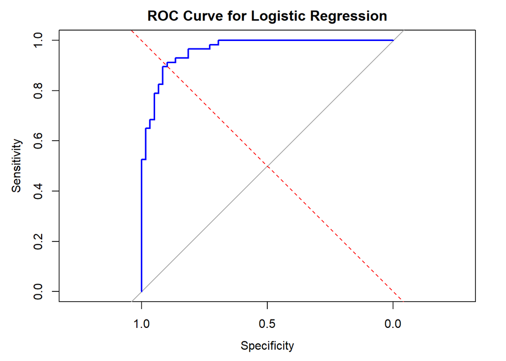

```r
# Plot ROC Curve
plot(roc_curve, main = "ROC Curve for Logistic Regression", col = "blue")
abline(a = 0, b = 1, lty = 2, col = "red")
```

```r
# LINEAR REGRESSION FOR NUMBER OF GAMES

train_data_norm$num_games <- as.numeric(as.character(train_data_norm$num_games))
test_data_norm$num_games <- as.numeric(as.character(test_data_norm$num_games))

# Fit linear regression model
games_model <- lm(num_games ~ ., data = train_data_norm %>% select(all_of(selected_features_games_lm), num_games))

predicted_games <- predict(games_model, newdata = test_data_norm %>% select(all_of(selected_features_games_lm)))

predicted_games <- round(predicted_games)

# Clamp predictions to be between 4 and 7
predicted_games <- pmax(pmin(predicted_games, 7), 4)

# Calculate RMSE for linear regression predictions
lin_rmse <- sqrt(mean((predicted_games - test_data_norm$num_games)^2))

print(paste("Linear Regression RMSE:", round(lin_rmse, 2)))
```

```
## [1] "Linear Regression RMSE: 1.13"
```

## Part C.) Fitting both random forests model (win_series) and (num_games) and then analysis

```r
# RANDOM FORESTS MODEL FOR SERIES WINNER

# Perform RFE to select top features
control_rf <- rfeControl(functions = rfFuncs, method = "cv", number = 10)

results_win_rf <- rfe(train_data_norm %>% select(-series_win, -num_games), train_data_norm$series_win,
                      sizes = c(1:35), rfeControl = control_rf)

selected_features_win_rf <- predictors(results_win_rf)

# Fit Random Forest model
rf_win_model <- randomForest(as.factor(series_win) ~ ., data = train_data_norm %>% select(all_of(selected_features_win_rf), series_win), ntree = 100)
rf_win_predictions <- predict(rf_win_model, newdata = test_data_norm %>% select(all_of(selected_features_win_rf)))
rf_win_probabilities <- predict(rf_win_model, newdata = test_data_norm %>% select(all_of(selected_features_win_rf)), type = "prob")[,2]

# Measurments
rf_conf_matrix <- confusionMatrix(rf_win_predictions, as.factor(test_data_norm$series_win))
rf_roc_curve <- roc(test_data_norm$series_win, rf_win_probabilities)
rf_auc <- auc(rf_roc_curve)

rf_precision <- rf_conf_matrix$byClass['Pos Pred Value']
rf_recall <- rf_conf_matrix$byClass['Sensitivity']
rf_f1 <- 2 * ((rf_precision * rf_recall) / (rf_precision + rf_recall))

print(rf_conf_matrix)
```

```
## Confusion Matrix and Statistics
##
##           Reference
## Prediction  0  1
##          0 53  8
##          1  6 49
##
##                Accuracy : 0.8793
##                  95% CI : (0.8058, 0.9324)
##     No Information Rate : 0.5086
##     P-Value [Acc > NIR] : <2e-16
##
##                   Kappa : 0.7584
##
##  Mcnemar's Test P-Value : 0.7893
##
##             Sensitivity : 0.8983
##             Specificity : 0.8596
##          Pos Pred Value : 0.8689
##          Neg Pred Value : 0.8909
##              Prevalence : 0.5086
##          Detection Rate : 0.4569
##    Detection Prevalence : 0.5259
##       Balanced Accuracy : 0.8790
##
##        'Positive' Class : 0
##
```

```r
print(paste("Random Forest AUC-ROC:", rf_auc))
```

```
## [1] "Random Forest AUC-ROC: 0.934284864704133"
```

```r
print(paste("Precision:", round(rf_precision, 3)))
```

```
## [1] "Precision: 0.869"
```

```r
print(paste("Recall:", round(rf_recall, 3)))
```

```
## [1] "Recall: 0.898"
```

```r
print(paste("F1 Score:", round(rf_f1, 3)))
```

```
## [1] "F1 Score: 0.883"
```

```r
print(paste("AUC-ROC:", round(rf_auc, 3)))
```

```
## [1] "AUC-ROC: 0.934"
```

```r
#RANDOM FORESTS FOR NUMBER OF GAMES


results_games_rf <- rfe(train_data_norm %>% select(-series_win, -num_games), train_data_norm$num_games,
                        sizes = c(1:35), rfeControl = control_rf)
```

[output not shown]

[output cut: 667 more lines]

[output not shown]

```r
selected_features_games_rf <- predictors(results_games_rf)

# Fit Random Forest model
rf_games_model <- randomForest(num_games ~ ., data = train_data_norm %>% select(all_of(selected_features_games_rf), num_games), ntree = 100)
rf_predicted_games <- predict(rf_games_model, newdata = test_data_norm %>% select(all_of(selected_features_games_rf)))

rf_predicted_games <- pmax(pmin(round(rf_predicted_games), 7), 4)

# Measurements
rf_mae <- mean(abs(rf_predicted_games - test_data_norm$num_games))
rf_mse <- mean((rf_predicted_games - test_data_norm$num_games)^2)
rf_rmse <- sqrt(rf_mse)

print(paste("Random Forest MAE:", round(rf_mae, 2)))
```

```
## [1] "Random Forest MAE: 0.69"
```

```r
print(paste("Random Forest MSE:", round(rf_mse, 2)))
```

```
## [1] "Random Forest MSE: 0.81"
```

```r
print(paste("Random Forest RMSE:", round(rf_rmse, 2)))
```

```
## [1] "Random Forest RMSE: 0.9"
```

## Part D.) Visualizations comparing Models

- Based on the plot below I decided to use the logistic regression model for predicting series_win (win_percentage) and random forests for num_games (number of games in series)

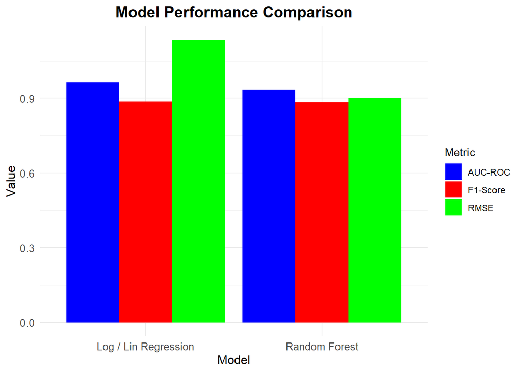

```r
model_names <- c("Log / Lin Regression", "Random Forest")
F1_scores <- c(f1_score, rf_f1)  # Ensure these variables are defined
auc_values <- c(auc_roc, rf_auc)  # Ensure these variables are defined
rmse_values <- c(lin_rmse, rf_rmse)  # Ensure these variables are defined

auc_data <- data.frame(
  Model = model_names,
  Metric = "AUC-ROC",
  Value = auc_values
)

f1_data <- data.frame(
  Model = model_names,
  Metric = "F1-Score",
  Value = F1_scores
)

rmse_data <- data.frame(
  Model = model_names,
  Metric = "RMSE",
  Value = rmse_values
)

plot_data <- rbind(auc_data, f1_data, rmse_data)

ggplot(plot_data, aes(x = Model, y = Value, fill = Metric)) +
  geom_bar(stat = "identity", position = "dodge") +
  labs(title = "Model Performance Comparison",
       x = "Model",
       y = "Value") +
  theme_minimal() +
  theme(
    plot.title = element_text(hjust = 0.5, size = 15, face = "bold"),
    axis.title = element_text(size = 12),
    axis.text = element_text(size = 10)
  ) +
  scale_fill_manual(values = c("AUC-ROC" = "blue", "F1-Score" = "red", "RMSE" = "green"))
```

```r
# Filter playoff series data for the 2022 season
playoff_series_data_2022 <- playoff_series_data %>%
  filter(season == 2022)

identifiers_2022 <- playoff_series_data_2022 %>%
  select(series_id, team_id, gametype, team_name, opponent_id, opponent, first_series_date)

playoff_series_features_2022 <- playoff_series_data_2022 %>%
  select(-series_id, -team_id, -gametype, -team_name, -opponent_id, -opponent, -series_win)

finite_filter <- is.finite(playoff_series_features_2022$avg_starter_ft_rate)
playoff_series_features_2022 <- playoff_series_features_2022[finite_filter, ]
identifiers_2022 <- identifiers_2022[finite_filter, ]

playoff_series_features_2022 <- playoff_series_features_2022 %>%
  mutate(Home_or_Away = ifelse(Home_or_Away == "Home", 1, 0))

series_win <- playoff_series_data_2022$series_win[finite_filter]
num_games <- playoff_series_data_2022$num_games[finite_filter]

preProc_2022 <- preProcess(playoff_series_features_2022, method = c("center", "scale"))
playoff_features_norm_2022 <- predict(preProc_2022, playoff_series_features_2022)

playoff_features_norm_2022$first_series_date <- as.numeric(as.Date(playoff_series_features_2022$first_series_date))

playoff_data_norm_2022 <- cbind(playoff_features_norm_2022, series_win = series_win, num_games = num_games)

playoff_data_norm_2022$series_win <- as.factor(playoff_data_norm_2022$series_win)
```

```r
# Model Creations
win_probabilities_2022 <- predict(cv_fit_win, newx = as.matrix(playoff_data_norm_2022 %>% select(all_of(selected_features_win_lr))),
                                  s = "lambda.min", type = "response")

predicted_games_2022 <- predict(rf_games_model, newdata = playoff_data_norm_2022 %>% select(all_of(selected_features_games_rf)))
predicted_games_2022 <- pmax(pmin(round(predicted_games_2022), 7), 4)

predictions_2022 <- identifiers_2022 %>%
  mutate(predicted_win_prob = win_probabilities_2022,
         predicted_num_games = predicted_games_2022)
```

[figure not shown]

```r
# Visualization Creation

teams <- unique(c(predictions_2022$team_name, predictions_2022$opponent))
advancement_probabilities <- data.frame(
  team = teams,
  round_1 = rep(0, length(teams)),
  round_2 = rep(0, length(teams)),
  round_3 = rep(0, length(teams)),
  round_4 = rep(0, length(teams))
)

for (team in teams) {
  round_1_prob <- predictions_2022 %>%
    filter(team_name == team | opponent == team) %>%
    summarise(prob = sum(predicted_win_prob)) %>%
    pull(prob)

  round_2_prob <- round_1_prob * 0.5  # Assuming independent probabilities, adjust as needed
  round_3_prob <- round_2_prob * 0.5
  round_4_prob <- round_3_prob * 0.5

  advancement_probabilities <- advancement_probabilities %>%
    mutate(
      round_1 = ifelse(team == !!team, round_1_prob, round_1),
      round_2 = ifelse(team == !!team, round_2_prob, round_2),
      round_3 = ifelse(team == !!team, round_3_prob, round_3),
      round_4 = ifelse(team == !!team, round_4_prob, round_4)
    )
}

advancement_probabilities_melted <- melt(advancement_probabilities, id.vars = "team")

ggplot(advancement_probabilities_melted, aes(x = team, y = value, fill = variable)) +
  geom_bar(stat = "identity", position = "dodge") +
  labs(title = "Advancement Probabilities for 2024 NBA Playoffs", x = "Team", y = "Probability", fill = "Round") +
  theme(axis.text.x = element_text(angle = 45, hjust = 1))
```

## Part F: Model Debrief

### Overview of Part 2

#### Data Manipulation

##### Player Data

- **Datasets Used**: `team_data` and `player_data`.
- **Aggregation**: Individual player data from team starters was averaged to bring it to the team level and then to the series level. Features related to this are tagged as “avg_starter”.

##### Team Data

- **Aggregation**: Data was aggregated into a single column format with home and away stats. New features were created when the data was in a single row, then split back into two separate rows distinguished by team, providing offense and defense stats for each team in the same row.

#### Feature Engineering

Features created include team aggregates, avg_starter aggregates, last_7_games aggregates, and past_season aggregates. This approach allows the model to determine which time frames are most important for different stats. Examples include:

- `avg_starter_playoff_games_played_before`: Sums the number of playoff games each starter had played before and averages it.
- `avg_ppp`: Team-level aggregation for Points Per Possession, averaged across the series.
- `first_last_7_games_point_differential`: Sums the team’s point differential over the past 7 games.
- `first_season_shooting_fouls_drawn`: Season-long aggregate of the sum of shooting fouls drawn by the team.

#### Normalization

After data cleaning, feature engineering, and formatting, all data was normalized to ensure comparable scales across all features.

### Model Creation

#### Win Probability Model

- **Model Used**: Logistic Regression.
- **Feature Selection**: Recursive feature elimination (RFE) was used to identify the most relevant features, ensuring the model remains interpretable and simple.
- **Validation**: Cross-validation was used to tune the regularization parameter, ensuring robust performance across different subsets of data.
- **Comparison**: The logistic regression model was compared with a random forest model. Although both performed similarly, the logistic regression model was preferred for its simplicity and ability to pick up important trends without becoming overfit or overly complex.

### Strengths of the Model

- **Comprehensive Metrics**: The model uses a comprehensive selection of performance metrics to capture all aspects of team performance during the playoffs.
- **Feature Selection**: Implementing a feature selection process ensures only the most relevant features are included in the final model.
- **Adaptability**: The model is designed to be easily updated with new data, ensuring it remains accurate and relevant for future seasons.

### Addressing the Weaknesses

Enhancing the model with these improvements—using regular season data, cleaner code, and better injury features—would significantly boost its predictive accuracy and reliability.